# Exploratory Data Analysis

Dr. Benjamin Odoi

2023-09-01

## Installations

Install required libraries for obtaining summary statistics and plotting graphics.

```r
# install.packages("summarytools")
# install.packages("tidyverse")
# install.packages("ggplot2")
# install.packages("moments")
```

## Loading Libaries

```r
library(summarytools)
library(tidyverse)
library(corrplot)
library(ggplot2)
library(dplyr)
```

### Load Data for Exploration

This dataset contains information on all accidents, injuries and illnesses reported by mine operators and contractors beginning on 1/1/2000. The data in the table is obtained from the Mine Accident, Injury and Illness Report form (MSHA Form 7000-1). Document number is the unique key for this data. It provides information about the accident/injury/illness such as type, mine location, lost days and the degree of injury.

- Link: https://arlweb.msha.gov/opengovernmentdata/DataSets/Accidents.zip
- The file was downloaded and unzipped to make the files available for the analysis
- The dataset was in text format but was converted to a csv file using the excel software, this was required as the it was cumbersome for R to read the text file directly. This is an optional step you might want to consider in the process of converting your file into a format that is easy to work with your analysis tools.

```r
path_to_file <- "C:/Users/Student/Downloads/Datasets Doi/Accidents.csv"
mine_accidents <- read.csv(path_to_file, header=TRUE, sep = ',') # The dataset is loaded into a dataframe which is easier to work with.
attach(mine_accidents)
```

### **Analysis Process**

In order to gain the most out of the dataset we would follow a simple framework to guide us in the analysis. The framework is as follows:

1. Identify the problem, or question we want to solve or answer using the data
2. Identify the data available to us, that can be useful in solving the problem.
3. Prepare the data set to ensure it is, relevant, complete and accurate

Before starting with any form of analysis it is important that we understand the content of the dataset.

- The `head` function is used to take a snapshot of the dataset to see some of the values it contains.

```r
# First 10 observations or rows in the data set
head(mine_accidents, 3)
```

```
##   MINE_ID CONTROLLER_ID                               CONTROLLER_NAME
## 1  100003       0041044                                  Lhoist Group
## 2  100003       0041044                                  Lhoist Group
## 3  100009        M00024 Legacy Vulcan Corp (Form:Vulcan Materials Co)
##   OPERATOR_ID                        OPERATOR_NAME CONTRACTOR_ID DOCUMENT_NO
## 1      L13586 Lhoist North America of Alabama, LLC           MPH 2.20132e+11
## 2      L13586 Lhoist North America of Alabama, LLC               2.20231e+11
## 3      L16168   Vulcan Construction Materials, LLC               2.20053e+11
##   SUBUNIT_CD                SUBUNIT ACCIDENT_DT CAL_YR CAL_QTR FISCAL_YR
## 1          3 STRIP, QUARY, OPEN PIT   8/12/2013   2013       3      2013
## 2          3 STRIP, QUARY, OPEN PIT   3/31/2022   2022       1      2022
## 3          3 STRIP, QUARY, OPEN PIT  11/13/2005   2005       4      2006
##   FISCAL_QTR ACCIDENT_TIME DEGREE_INJURY_CD                 DEGREE_INJURY
## 1          4          1815               05 DAYS RESTRICTED ACTIVITY ONLY
## 2          2          1430               03      DAYS AWAY FROM WORK ONLY
```

[output cut: 53 more lines]

We have a lot of columns in our dataset, it would be appropriate for us to see all the columns available and understand what they mean.

- The `names` function gives the names of all the columns present in the dataset.

```r
names(mine_accidents)
```

```
##  [1] "MINE_ID"             "CONTROLLER_ID"       "CONTROLLER_NAME"
##  [4] "OPERATOR_ID"         "OPERATOR_NAME"       "CONTRACTOR_ID"
##  [7] "DOCUMENT_NO"         "SUBUNIT_CD"          "SUBUNIT"
## [10] "ACCIDENT_DT"         "CAL_YR"              "CAL_QTR"
## [13] "FISCAL_YR"           "FISCAL_QTR"          "ACCIDENT_TIME"
## [16] "DEGREE_INJURY_CD"    "DEGREE_INJURY"       "FIPS_STATE_CD"
## [19] "UG_LOCATION_CD"      "UG_LOCATION"         "UG_MINING_METHOD_CD"
## [22] "UG_MINING_METHOD"    "MINING_EQUIP_CD"     "MINING_EQUIP"
## [25] "EQUIP_MFR_CD"        "EQUIP_MFR_NAME"      "EQUIP_MODEL_NO"
## [28] "SHIFT_BEGIN_TIME"    "CLASSIFICATION_CD"   "CLASSIFICATION"
## [31] "ACCIDENT_TYPE_CD"    "ACCIDENT_TYPE"       "NO_INJURIES"
## [34] "TOT_EXPER"           "MINE_EXPER"          "JOB_EXPER"
## [37] "OCCUPATION_CD"       "OCCUPATION"          "ACTIVITY_CD"
## [40] "ACTIVITY"            "INJURY_SOURCE_CD"    "INJURY_SOURCE"
## [43] "NATURE_INJURY_CD"    "NATURE_INJURY"       "INJ_BODY_PART_CD"
## [46] "INJ_BODY_PART"       "SCHEDULE_CHARGE"     "DAYS_RESTRICT"
## [49] "DAYS_LOST"           "TRANS_TERM"          "RETURN_TO_WORK_DT"
## [52] "IMMED_NOTIFY_CD"     "IMMED_NOTIFY"        "INVEST_BEGIN_DT"
## [55] "NARRATIVE"           "CLOSED_DOC_NO"       "COAL_METAL_IND"
```

Some description of the columns in the data set

> MINE_ID: Identification number assigned to the mine by MSHA. It is the mine identification number of the mine where the accident/injury/illness occurred.

> CONTROLLER_ID: Identification number assigned by MSHA Assessments for a Legal Entity acting as a controller of an operator at the time of the accident.

> CONTROLLER_NAME: Name of the controller active at the time of the accident.

> SUBUNIT_CD: Code that identifies the location within a mine where the accident/injury/illness occurred.

> SUBUNIT: Description of the subunit code referring to the location within a mine where the accident/injury/illness occurred: (01) Underground; (02) Surface at underground; (03) Strip, quarry, open pit; (04) Auger; (05) Culm bank/refuse pile; (06) Dredge; (12) Other mining; (17) Independent shops or yards; (30) Mill operation/preparation plant; (99) Office workers at mine site.

> ACCIDENT_DT: Date the accident/injury/illness occurred (mm/dd/yyyy).

> ACCIDENT_TIME: Time the accident/injury/illness occurred (24-hour clock).

> DEGREE_INJURY: Description of the degree of injury/illness to the individual: (00) Accident only; (01) Fatality; (02) Permanent total or permanent partial disability; (03) Days away from work only; (04) Days away from work and restricted activity; (05) Days restricted activity only; (06) No days away from work, no restrictions; (07) Occupational illness not degree 1-6; (08) Injuries due to natural causes; (09) Injuries involving non-employees; (10) All other cases (incl. 1st aid); (?) No value found.

> UG_LOCATION|: Description of the underground location code where the accident/injury/illness occurred: (01) Vertical shaft; (02) Slope/inclined shaft; (03) Face; (04) Intersection; (05) Underground shop/office; (06) Last open crosscut; (07) Inby permanent support; (08) Haulageway; (09) Other entry (not haulageway); (98) Other; (99) Not Marked; (?) No value found.

> UG_MINING_METHOD_CD: Description of the underground mining method code where the accident/injury/illness occurred.

> UG_MINING_METHOD: Description of the underground mining method code where the accident/injury/illness occurred: (01) Longwall; (02) Shortwall; (03) Conventional Stoping; (05) Continuous Miner; (06) Hand; (07) Caving; (08) Other; (?) No Value Found.

The `str` functions is handy in obtaining a description of the data set.

The output of this function shows the data types of the variables. This is our chance to identify any miss representations of the data in our data frame, example: date column being formatted as a character.

> **Data types**
> 1. Numeric (double): Represents numeric values, including both integers and decimals. Example: `3.14`, `123`, `-0.5`
> 2. Integer: Represents whole numbers (integers). Example: `10`, `-42`, `0`
> 3. Character (char): Represents strings of text or characters. Example: `"Hello, world!"`, `"John Doe"`, `"R Programming"`
> 4. Logical (logical): Represents Boolean values, `TRUE` or `FALSE`. Example: `TRUE`, `FALSE`
> 5. Factor: Represents categorical data with levels or categories. Example: `factor("Male", levels = c("Male", "Female"))`
> 6. Date: Represents date values. Example: `as.Date("2023-08-28")`
> 7. POSIXct and POSIXlt: Represent date and time values with time zone information. Example: `as.POSIXct("2023-08-28 14:30:00", tz = "UTC")`
> 8. Complex: Represents complex numbers with real and imaginary parts. Example: `1 + 2i`, `-3 + 4i`
> 9. Raw: Represents raw bytes of data. Example: `as.raw(c(0x41, 0x42, 0x43))`
> 10. Lists: Ordered collections of objects (can be of different types). Example: `list(1, "apple", TRUE, c(1, 2, 3))`
> 11. Vectors: Basic building blocks in R, can hold values of the same type. Example: `c(1, 2, 3, 4, 5)`
> 12. Matrices: 2-dimensional arrays with rows and columns. Example: `matrix(c(1, 2, 3, 4), nrow = 2, ncol = 2)`
> 13. Arrays: Multi-dimensional generalization of matrices. Example: `array(1:24, dim = c(2, 3, 4))`
> 14. Data Frames: Tabular data structures with rows and named columns (like a spreadsheet). Example: `data.frame(Name = c("Alice", "Bob"), Age = c(25, 30))`

```r
str(mine_accidents)
```

```
## 'data.frame':    257041 obs. of  57 variables:
##  $ MINE_ID            : int  100003 100003 100009 100011 100011 100011 100016 100027 100027 100027 ...
##  $ CONTROLLER_ID      : chr  "0041044" "0041044" "M00024" "M11763" ...
##  $ CONTROLLER_NAME    : chr  "Lhoist Group" "Lhoist Group" "Legacy Vulcan Corp (Form:Vulcan Materials Co)" "Imerys S A" ...
##  $ OPERATOR_ID        : chr  "L13586" "L13586" "L16168" "L17074" ...
##  $ OPERATOR_NAME      : chr  "Lhoist North America of Alabama, LLC" "Lhoist North America of Alabama, LLC" "Vulcan Construction Materials, LLC" "Imerys Pigments LLC" ...
##  $ CONTRACTOR_ID      : chr  "MPH" "" "" "" ...
##  $ DOCUMENT_NO        : num  2.2e+11 2.2e+11 2.2e+11 2.2e+11 2.2e+11 ...
##  $ SUBUNIT_CD         : int  3 3 3 30 30 30 30 30 30 30 ...
##  $ SUBUNIT            : chr  "STRIP, QUARY, OPEN PIT" "STRIP, QUARY, OPEN PIT" "STRIP, QUARY, OPEN PIT" "MILL OPERATION/PREPARATION PLANT" ...
##  $ ACCIDENT_DT        : chr  "8/12/2013" "3/31/2022" "11/13/2005" "7/14/2006" ...
##  $ CAL_YR             : int  2013 2022 2005 2006 2009 2010 2002 2002 2004 2009 ...
##  $ CAL_QTR            : int  3 1 4 3 1 1 2 2 1 4 ...
##  $ FISCAL_YR          : int  2013 2022 2006 2006 2009 2010 2002 2002 2004 2010 ...
##  $ FISCAL_QTR         : int  4 2 1 4 2 2 3 3 2 1 ...
```

[output cut: 43 more lines]

From the output we observe that ACCIDENT_DT is being represented as a character instead of a date type. we would later see how to convert it to the appropriate type.

The above step is necessary as it allows us to:

1. better understand the data we want to work with.
2. identify those columns that might contain the data we believe can help us answer the analysis question.
3. select the data you want to work with.
4. convert the misrepresented data types to the appropriate types for the analysis

### Problem Identification

> Lets assume management is worried about the number of accidents occurring at the various mine sites. They would want to understand where the accidents are occurring , when they occur and the type of injury sustained.

> They want to also understand the type of mining methods used in those mine sites where the accidents occur so that they can adopt better mining methods at those sites.

The insight you gain from this analysis would help your stakeholders (managers) gain better understanding of the accidents situation in the mines and take positive actions, that would benefit yourself and others.

With the problem and analysis objective clear in mined we can now start processing data for analysis.

### Data Cleaning

Before we can clean the data we must first know what sort of ‘dirt’ is in the data, the above step of describing the data set helped us identify some issues like :

- Wrong data types of columns and
- Missing values (?).

#### Summary Statistics

Our next step involves using summary statistics to understand our data.

The summary function gives a statistical summary of the data

> - Min: The minimum value in the data.
> - 1st Qu: The first quartile, also known as the 25th percentile.
> - Median: The median, which is the 50th percentile.
> - Mean: The arithmetic mean (average) of the data.
> - 3rd Qu: The third quartile, or the 75th percentile.
> - Max: The maximum value in the data.
> - NA’s: The count of missing values.

```r
# Display summary using summary() function
data_summary <- summary(mine_accidents)
print(data_summary)
```

```
##     MINE_ID        CONTROLLER_ID      CONTROLLER_NAME    OPERATOR_ID
##  Min.   : 100003   Length:257041      Length:257041      Length:257041
##  1st Qu.:1202418   Class :character   Class :character   Class :character
##  Median :2700083   Mode  :character   Mode  :character   Mode  :character
##  Mean   :2690853
##  3rd Qu.:4400093
##  Max.   :6900001
##
##  OPERATOR_NAME      CONTRACTOR_ID       DOCUMENT_NO          SUBUNIT_CD
##  Length:257041      Length:257041      Min.   :2.200e+11   Min.   : 1.000
##  Class :character   Class :character   1st Qu.:2.200e+11   1st Qu.: 1.000
##  Mode  :character   Mode  :character   Median :2.201e+11   Median : 3.000
##                                        Mean   :2.201e+11   Mean   : 9.485
##                                        3rd Qu.:2.201e+11   3rd Qu.:30.000
##                                        Max.   :2.202e+11   Max.   :99.000
##
##    SUBUNIT          ACCIDENT_DT            CAL_YR        CAL_QTR
##  Length:257041      Length:257041      Min.   :2000   Min.   :1.00
##  Class :character   Class :character   1st Qu.:2003   1st Qu.:1.00
##  Mode  :character   Mode  :character   Median :2008   Median :2.00
##                                        Mean   :2009   Mean   :2.46
##                                        3rd Qu.:2014   3rd Qu.:3.00
##                                        Max.   :2023   Max.   :4.00
##
##    FISCAL_YR      FISCAL_QTR    ACCIDENT_TIME  DEGREE_INJURY_CD
##  Min.   :2000   Min.   :1.000   Min.   :   0   Length:257041
##  1st Qu.:2004   1st Qu.:2.000   1st Qu.: 845   Class :character
##  Median :2008   Median :3.000   Median :1220   Mode  :character
##  Mean   :2009   Mean   :2.581   Mean   :1867
##  3rd Qu.:2014   3rd Qu.:4.000   3rd Qu.:1730
##  Max.   :2023   Max.   :4.000   Max.   :9999
##                                 NA's   :1
##  DEGREE_INJURY      FIPS_STATE_CD   UG_LOCATION_CD     UG_LOCATION
##  Length:257041      Min.   : 1.00   Length:257041      Length:257041
##  Class :character   1st Qu.:18.00   Class :character   Class :character
##  Mode  :character   Median :32.00   Mode  :character   Mode  :character
##                     Mean   :32.32
##                     3rd Qu.:49.00
##                     Max.   :78.00
##
```

[output cut: 65 more lines]

```
##  Length:257041      Length:257041      Length:257041      Min.   :3.200e+10
##  Class :character   Class :character   Class :character   1st Qu.:3.200e+11
##  Mode  :character   Mode  :character   Mode  :character   Median :3.201e+11
##                                                           Mean   :3.201e+11
##                                                           3rd Qu.:3.202e+11
##                                                           Max.   :3.202e+11
##                                                           NA's   :143885
##  COAL_METAL_IND
##  Length:257041
##  Class :character
##  Mode  :character
##
##
##
##
```

From the the output we realize that

- the years in consideration is from 2000 to 2023
- the experience of injured mine workers in a mine ranges from less than a month to over 65 months.

There a lot of insights to be gleaned from the summary statistics. For the purpose of data cleaning we observe that:

The data cleaning processes that we can identify to undertake using this information includes:

> 1. Missing Values: The `NA's` count in the `summary()` output indicates the number of missing values for each variable. Identifying missing values can guide you in deciding how to handle them, whether by imputing missing values, removing rows with missing values, or using appropriate techniques.
> 2. Outliers: By looking at the minimum and maximum values, as well as quartiles (1st Qu, 3rd Qu), you can identify potential outliers. Outliers can be erroneous data points or indicate interesting phenomena. You might need to decide whether to keep, transform, or remove outliers.
> 3. Data Distribution: Summary statistics like mean, median, and quartiles provide insights into the distribution of the data. Skewed distributions might require transformations for normalization.
> 4. Data Type Mismatches: If summary statistics for a variable don’t make sense (e.g., mean and quartiles for a categorical variable), it could indicate a data type mismatch that needs correction.
> 5. Data Range Issues: If the range of values seems unexpected (e.g., negative age values), it might indicate data entry errors that require investigation.
> 6. Data Consistency: Comparing summary statistics across related variables (e.g., age and birth year) can help identify inconsistencies that need correction.
> 7. Data Scale: Discrepancies in the scale of variables (e.g., one variable is in thousands while another is in single digits) might require normalization.
> 8. Categorical Variables: For categorical variables (factors), the `summary()` output can provide levels and counts, helping you identify rare or unexpected categories.
> 9. Variable Relationships: By comparing summary statistics across different variables, you might identify relationships that need further exploration or validation.
> 10. Sampling Errors: If the dataset is a sample, summary statistics can help you assess whether it accurately represents the population, or if sampling errors are present.
> 11. Data Consistency: For time-related data, identifying irregularities like negative timestamps or future dates can help improve data consistency.

Other summary statistics that are not provided by the summary function can be calculated as follows:

##### Standard Deviation and Variance

```r
# Calculate summary statistics for specific columns
summary_stats <- mine_accidents %>%
  summarise(
    # Min_MINE_EXPER = min(MINE_EXPER, na.rm = TRUE),
    # Max_MINE_EXPER = max(MINE_EXPER, na.rm = TRUE),
    # Median_MINE_EXPER = median(MINE_EXPER, na.rm = TRUE),
    # Mean_MINE_EXPER = mean(MINE_EXPER, na.rm = TRUE),
    SD_MINE_EXPER = sd(MINE_EXPER, na.rm = TRUE),
    Variance_MINE_EXPER = var(MINE_EXPER, na.rm = TRUE)
  )

# Print the summary statistics
print(summary_stats)
```

```
##   SD_MINE_EXPER Variance_MINE_EXPER
## 1      8.693857            75.58315
```

- A standard deviation of 8.693857 means that, on average, a mine worker’s experience deviates from the mean experience by approximately 8.69 months.
- A smaller standard deviation suggests that the data points are closer to the mean, indicating less variability in experience levels.

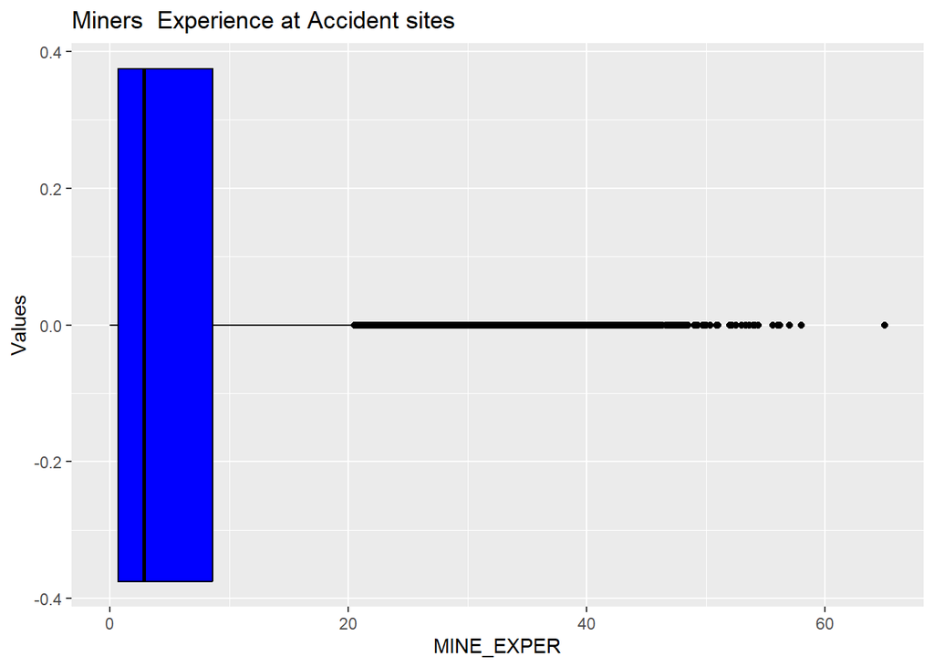

```r
# Visualize Varience and Standard Deviation with a box and whisker plot
ggplot(mine_accidents, aes(x = MINE_EXPER)) +
  geom_boxplot(fill = "blue", color = "black") +
  ggtitle("Miners  Experience at Accident sites") +
  ylab("Values")
```

> In a box plot, the box represents the IQR, and whiskers extend to the minimum and maximum values within 1.5 times the IQR. Any data points outside the whiskers are considered potential outliers.
> - A wider box and longer whiskers indicate higher variance and standard deviation.
> - A narrow box and shorter whiskers indicate lower variance and standard deviation.

What insights do you deduce from the above plot?

We would later explore the relationship between experience level and the rate of accidents.

##### Skewness and Kurtosis

```r
library(moments)
```

```r
# Calculate skewness and kurtosis for the "Age" column
skewness_MINE_EXPER <- skewness(mine_accidents$MINE_EXPER, na.rm = TRUE)
kurtosis_MINE_EXPER <- kurtosis(mine_accidents$MINE_EXPER, na.rm = TRUE)

# Print the results
print(paste("Skewness MINE_EXPER:", skewness_MINE_EXPER))
```

```
## [1] "Skewness MINE_EXPER: 1.84514527002742"
```

```r
print(paste("Kurtosis MINE_EXPER:", kurtosis_MINE_EXPER))
```

```
## [1] "Kurtosis MINE_EXPER: 5.89573414638389"
```

1. **Skewness (1.84514527002742):**
   - Skewness measures the asymmetry of the distribution of data. Positive skewness (greater than 0) indicates that the data is skewed to the right, meaning that the tail on the right side of the distribution is longer or fatter than the left side.
   - In the context of mine worker experience, a skewness value of 1.84514527002742 suggests that there is a right skew in the data. This means that there may be a few mine workers with significantly more years of experience than the majority of workers, causing the distribution to be stretched out to the right.
   - Workers with extensive experience may be considered outliers or constitute a minority in the dataset.

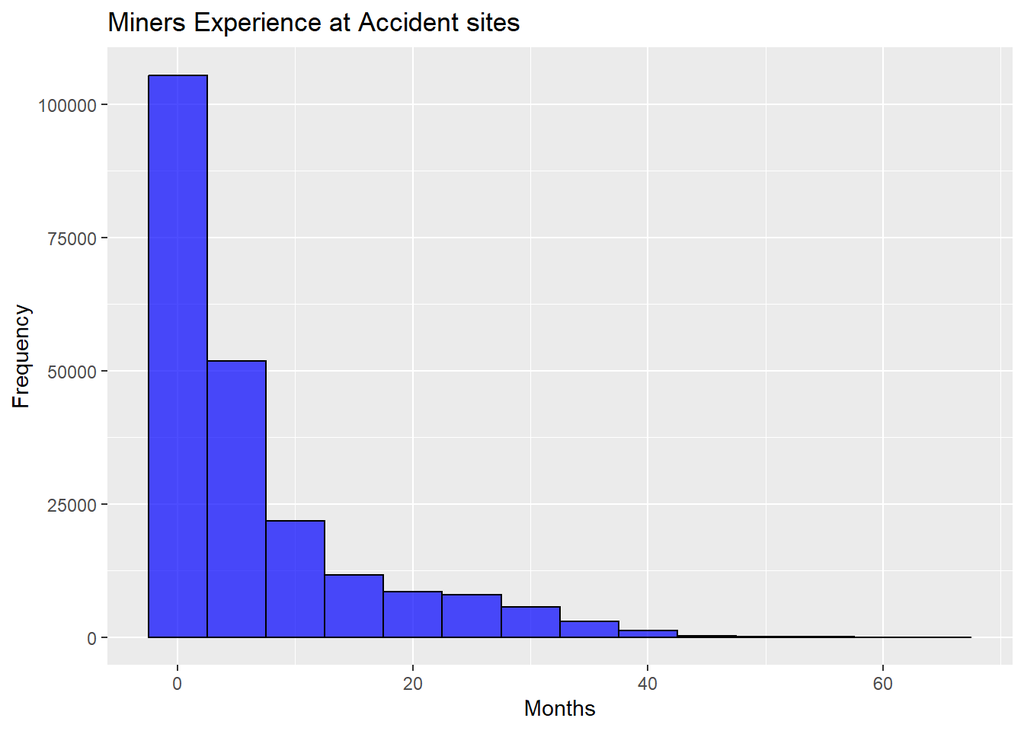

     ```r
     # Visualize skweness by plotting a histogram
     ggplot(mine_accidents, aes(x = MINE_EXPER)) +
       geom_histogram(binwidth = 5, fill = "blue", color = "black", alpha = 0.7) +
       ggtitle("Miners Experience at Accident sites") +
       xlab("Months") + ylab("Frequency")
     ```

2. **Kurtosis:**
   - Kurtosis measures the tailedness or peakedness of the distribution of data. A positive kurtosis value (greater than 3 for the normal distribution) indicates that the distribution has heavier tails and a sharper peak compared to a normal distribution.
   - In the context of mine worker experience, a kurtosis value of 5.89573414638389 suggests that the distribution has heavy tails and is more peaked than a normal distribution.
   - This can indicate that the dataset has more extreme values or outliers compared to a normal distribution, contributing to the heavy tails.

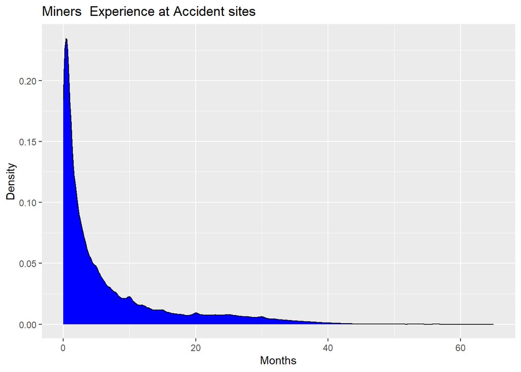

```r
# Visualize Kurtosis by plotting a Density plot
ggplot(mine_accidents, aes(x = MINE_EXPER)) +
 geom_density(fill = "blue", color = "black") +
  ggtitle("Miners  Experience at Accident sites") +
  xlab("Months") + ylab("Density")
```

With the above summary statistics in mind we will go ahead and perform the following data cleaning processes.

- Remove Duplicates
- Handle Missing Values
- Handle Missing Values
- Converting Data Types
- Select Relevant Data for Analysis

#### Remove Duplicates

Duplicates refer to rows or records with identical or nearly identical attribute values. Identifying and addressing duplicates is crucial for data quality and unbiased analysis results.

```r
# Check for duplicates
duplicates <- mine_accidents[duplicated(mine_accidents) | duplicated(mine_accidents, fromLast = TRUE), ]
print(duplicates[1:5])
```

```
##        MINE_ID CONTROLLER_ID                            CONTROLLER_NAME
## 6839   4101003        M00581                     Oglebay Norton Company
## 8461    404075        M00004                       Heidelberg Cement AG
## 12399   400158        M00004                       Heidelberg Cement AG
## 15430  4608159        C06656     Horizon Natural Resources Incorporated
## 16367   404075        M00004                       Heidelberg Cement AG
## 20961  1200090        M00452                           Rogers Group Inc
## 22242  3001712        M05813 Joseph Charles Tesiero; John A Tesiero III
## 39133  4400093        M01784                             Dennis W Perry
## 39443  4603317        C06656     Horizon Natural Resources Incorporated
## 42426  3400050        M06183                                    CRH PLC
## 57822  2100535       0119681                                 Holcim Ltd
## 83135  4400093        M01784                             Dennis W Perry
## 84446   400021        M06796                              Bill T  Dutra
## 96568   400158        M00004                       Heidelberg Cement AG
```

[output cut: 65 more lines]

Thare are a couple of duplicate rows in the dataset, but remember that the dicision to remove such duplicates may depend on your knowledge of the data and its collection processes.

```r
# Remove duplicates
cleaned_data <- mine_accidents %>%
  distinct()
```

#### Handle Missing Values

“missing values” refer to the absence of data for one or more attributes (columns) in a dataset where data should ideally be present. These missing values can occur for various reasons and are a common issue in real-world datasets. Understanding and appropriately handling missing values is crucial for accurate and reliable data analysis.

```r
# Check for missing or null values
missing_values <- cleaned_data %>%
  summarise_all(~ sum(is.na(.)))

print(missing_values)
```

```
##   MINE_ID CONTROLLER_ID CONTROLLER_NAME OPERATOR_ID OPERATOR_NAME CONTRACTOR_ID
## 1       0             0               0           0             0             0
##   DOCUMENT_NO SUBUNIT_CD SUBUNIT ACCIDENT_DT CAL_YR CAL_QTR FISCAL_YR
## 1           0          0       0           0      0       0         0
##   FISCAL_QTR ACCIDENT_TIME DEGREE_INJURY_CD DEGREE_INJURY FIPS_STATE_CD
## 1          0             1                0             0             0
##   UG_LOCATION_CD UG_LOCATION UG_MINING_METHOD_CD UG_MINING_METHOD
## 1              0           0                   0                0
##   MINING_EQUIP_CD MINING_EQUIP EQUIP_MFR_CD EQUIP_MFR_NAME EQUIP_MODEL_NO
## 1               0            0            0              0            101
##   SHIFT_BEGIN_TIME CLASSIFICATION_CD CLASSIFICATION ACCIDENT_TYPE_CD
## 1              990                 0              0                0
##   ACCIDENT_TYPE NO_INJURIES TOT_EXPER MINE_EXPER JOB_EXPER OCCUPATION_CD
## 1             0          24     42704      39777     38997             0
##   OCCUPATION ACTIVITY_CD ACTIVITY INJURY_SOURCE_CD INJURY_SOURCE
## 1          0           0        0                0             0
##   NATURE_INJURY_CD NATURE_INJURY INJ_BODY_PART_CD INJ_BODY_PART SCHEDULE_CHARGE
## 1                0             0                0             0           65029
##   DAYS_RESTRICT DAYS_LOST TRANS_TERM RETURN_TO_WORK_DT IMMED_NOTIFY_CD
## 1         59847     44762          0                 0               0
##   IMMED_NOTIFY INVEST_BEGIN_DT NARRATIVE CLOSED_DOC_NO COAL_METAL_IND
## 1            0               0         1        143867              0
```

Some columns have significantly high number of missing values, given that the dataset contains 257041 observations.

Some of the ways to handle missing values include:

- Deleting the the rows with missing values
- Imputing the the missing values, eg. mean imputation
- Interpolation and Extrapolation
- Forward Fill and Backward Fill (Time-Series Data)

We choose to remove the rows with missing values.

```r
# Remove rows with missing values in "MINE_EXPER" column
# is.na() returns the rows with missing or null values
# The ! means filter out those rows without missing values
cleaned_data  <- cleaned_data %>%
  filter(!is.na(MINE_EXPER))
```

If you found out that a dataset you about to analyze has a lot of missing values in it, what actions would you take as a data analyst?